# Customer Segmentation Strategy

Transitioning from Mass Marketing to Targeted Campaigns

# **Introduction**

Dữ liệu được lấy từ [Customer Personality Analysis](https://www.kaggle.com/datasets/imakash3011/customer-personality-analysis) cung cấp bởi **Dr.Omar Romero - Hernandez**. Mô phỏng tình huống kinh doanh một công ty buôn bán các mặt hàng sản phẩm (Rượu, thịt, cá, …).

## **1. Business Context**

Công ty hiện đang sở hữu một tập dữ liệu về nhân khẩu học, hành vi mua sắm và phản hồi marketing của khách hàng trong vòng 2 năm.

Tuy nhiên, các chiến dịch trước đây được triển khai đồng loạt trên toàn bộ khách hàng dẫn đến:

- Chi phí cao.
- Tỷ lệ phản hồi thấp.
- Khó tối ưu sản phẩm, kênh bán hàng.

## **2. Business Task**

Xác định các phân khúc khách hàng dựa trên nhân khẩu học, hành vi mua sắm và trình bày các phân khúc khách hàng phản hồi chiến dịch marketing sắp tới nhằm tối ưu vận hành và phân bố nguồn lực bán hàng.

Diễn giải:

- Tìm tệp khách hàng giá trị thông qua việc phân tích đặc điểm hành vi và nhân khẩu học.
- Đo lường tỷ lệ phản hồi của các tệp khách hàng trong chiến dịch tới.
- Kênh bán hàng chủ lực, danh mục sản phẩm cần tập trung.

## **3. Business Questions**

Có thể chia tệp khách hàng như thế nào dựa trên:

- Nhân khẩu học.
- Hành vi mua sắm.

Tệp khách hàng nào:

- Chi tiêu nhiều.
- Giá trị cao.

Tỷ lệ phản hồi chiến dịch tiếp thị:

- Đặc điểm của tệp khách hàng tương tác các chiến dịch trước là gì.
- Đo lường tỷ lệ chấp thuận dự kiến cho chiến dịch sắp tới.

Kênh bán hàng, danh mục sản phẩm nào là chủ lực.

## **4. Deliverables**

Báo cáo phân tích: R Markdown -> HTML.

Biểu đồ:

- Customer segments.
- Spending patterns.
- Campaign response.

Danh sách recommendations:

- Nhóm ưu tiên chạy chiến dịch sắp tới.
- Gợi ý kênh bán hàng phù hợp.
- Các danh mục sản phẩm tiềm năng.

# **Executive Summary**

Dữ liệu về hành vi và giao dịch của khách hàng trong 2 năm qua đã xác định được nguyên nhân cốt lõi và mở ra nhận định: Không thể tiếp tục bán mọi thứ cho toàn bộ khách hàng.

Qua quá trình phân tích, Chân dung Khách hàng giá trị đã được định hình qua 3 góc nhìn:

**Nhân khẩu học**: Thu nhập càng cao sẽ có xu hướng chi tiêu càng nhiều. Tuy nhiên, mức độ chi tiêu và cấu trúc sản phẩm bị chi phối bởi cấu trúc gia đình (Có con/ Không con).

**Hành vi mua sắm**: Việc tung nhiều khuyến mãi trên toàn bộ tập khách hàng không cải thiện tốt doanh thu. Phần lớn bình quân chi tiêu tạo ra nguồn doanh thu giá trị ở nhóm khách hàng mua sắm không phụ thuộc vào khuyến mãi.

**Mức độ tương tác**: Tỷ lệ phản hồi Chiến dịch sắp tới ở nhóm mua giá gốc 41% theo sau là nhóm chuộng khuyến mãi vừa phải 27%.

**Kết luận**:

- Thu nhập cao không bị chi phối yếu tố con cái là Nhóm khách hàng giá trị, nguồn doanh thu cốt lõi.
- Nhóm khách hàng giá trị ưu tiên chất lượng sản phẩm hơn là các chương trình giảm giá.
- Họ thích trải nghiệm và sử dụng dịch vụ trực tiếp tại cửa hàng, chi tiêu mạnh vào những mặt hàng Rượu và Thịt.

# **Recommendations**

> **Target Marketing**
- **Tập trung ngân sách**: Xây dựng chiến dịch đặc quyền nhắm vào tệp khách hàng có thu nhập cao và không ảnh hưởng con cái.
- **Tối ưu kênh phân phối**: Nâng cấp chất lượng dịch vụ chăm sóc khách hàng tại kênh bán hàng Store.
- **Cá nhân hoá sản phẩm**: Đẩy mạnh quảng cáo các dòng Rượu vang. Cá nhân hoá mặt hàng Thịt theo tình trạng gia đình nhằm tối ưu chi phí.

# **Prepare**

## **1. Data Overview**

Cấu trúc dữ liệu gồm:

- Nhân khẩu học.
- Hành vi mua sắm theo nhóm sản phẩm.
- Số lần giao dịch các nền tảng: Web, Store, Catalog.
- Lịch sử tương tác với các chiến dịch marketing.

Phản ánh hành vi xu hướng chi tiêu của khách hàng và sự đồng hành ở các chiến dịch.

## **2. Metrics**

**Phân khúc khách hàng**

- Cấu trúc gia đình (Có con/ Không con).
- Học vị.
- Tổng chi tiêu.
- Tần suất giao dịch trong 2 năm qua.

**Nhóm Marketing**

- Tỷ lệ chấp thuận dự kiến cho chiến dịch tới.
- Tỷ lệ phản hồi các chiến dịch trước.
- Đánh giá mức độ sử dụng khuyến mãi.

**Nhóm kênh bán hàng**

- Tỷ trọng mua hàng theo từng kênh: Web, Store, Catalog.
- Danh mục sản phẩm: Phân bổ chi tiêu cho Rượu, Thịt, Cá,…

# **Processing**

## **1. Data Profiling**

Các thư viện được thiết lập:

- Xử lý dữ liệu: `tidyverse`, `dplyr`, `janitor`, `lubridate`.
- Trực quan hoá: `ggplot2`, `ggpubr`, `gridExtra`, `scales`.
- Báo cáo: `knitr`, `skimr`.

### Data Structure

Dữ liệu chứa:

- 2240 dòng mỗi dòng tương đương với một khách hàng.
- 29 các thuộc tính về thông tin cá nhân, hành vi mua sắm, đánh giá và phản hồi các chiến dịch marketing của khách hàng.

```r
glimpse(dataframe)
```

```
Rows: 2,240
Columns: 29
$ ID                  <int> 5524, 2174, 4141, 6182, 5324, 7446, 965, 6177, 485…
$ Year_Birth          <int> 1957, 1954, 1965, 1984, 1981, 1967, 1971, 1985, 19…
$ Education           <chr> "Graduation", "Graduation", "Graduation", "Graduat…
$ Marital_Status      <chr> "Single", "Single", "Together", "Together", "Marri…
$ Income              <int> 58138, 46344, 71613, 26646, 58293, 62513, 55635, 3…
$ Kidhome             <int> 0, 1, 0, 1, 1, 0, 0, 1, 1, 1, 1, 0, 0, 1, 0, 0, 1,…
$ Teenhome            <int> 0, 1, 0, 0, 0, 1, 1, 0, 0, 1, 0, 0, 0, 1, 0, 0, 1,…
$ Dt_Customer         <chr> "04-09-2012", "08-03-2014", "21-08-2013", "10-02-2…
$ Recency             <int> 58, 38, 26, 26, 94, 16, 34, 32, 19, 68, 11, 59, 82…
$ MntWines            <int> 635, 11, 426, 11, 173, 520, 235, 76, 14, 28, 5, 6,…
$ MntFruits           <int> 88, 1, 49, 4, 43, 42, 65, 10, 0, 0, 5, 16, 61, 2, …
$ MntMeatProducts     <int> 546, 6, 127, 20, 118, 98, 164, 56, 24, 6, 6, 11, 4…
$ MntFishProducts     <int> 172, 2, 111, 10, 46, 0, 50, 3, 3, 1, 0, 11, 225, 3…
```

[output cut: 16 more lines]

### Metrics Calculation

Khởi tạo các biến số cơ sở phục vụ cho quá trình kiểm định.

- Age.
- Family_Status (Childless/ Parent).
- Total_Spending.
- Total_Purchases.

```r
# Tuổi
dataframe <- dataframe %>%
  mutate(Age = 2026 - Year_Birth)

# Cấu trúc gia đình
dataframe <- dataframe %>%
  mutate(Family_Status = case_when(Kidhome + Teenhome > 0 ~ "Parent",
                                   TRUE ~ "Childless"))

# Tổng doanh thu sản phẩm
dataframe <- dataframe %>%
  mutate(Total_Spending =
           MntWines + MntFruits + MntMeatProducts + MntFishProducts +  MntSweetProducts + MntGoldProds)

# Tổng số lần mua hàng trên toàn bộ nền tảng.
dataframe <- dataframe %>%
  mutate(Total_Purchase = NumWebPurchases + NumCatalogPurchases + NumStorePurchases)
```

### Descriptive Statistics

```
       ID          Year_Birth    Education         Marital_Status
 Min.   :    0   Min.   :1893   Length:2240        Length:2240
 1st Qu.: 2828   1st Qu.:1959   Class :character   Class :character
 Median : 5458   Median :1970   Mode  :character   Mode  :character
 Mean   : 5592   Mean   :1969
 3rd Qu.: 8428   3rd Qu.:1977
 Max.   :11191   Max.   :1996

     Income          Kidhome          Teenhome      Dt_Customer
 Min.   :  1730   Min.   :0.0000   Min.   :0.0000   Length:2240
 1st Qu.: 35303   1st Qu.:0.0000   1st Qu.:0.0000   Class :character
 Median : 51382   Median :0.0000   Median :0.0000   Mode  :character
 Mean   : 52247   Mean   :0.4442   Mean   :0.5062
 3rd Qu.: 68522   3rd Qu.:1.0000   3rd Qu.:1.0000
 Max.   :666666   Max.   :2.0000   Max.   :2.0000
 NA's   :24
    Recency         MntWines         MntFruits     MntMeatProducts
 Min.   : 0.00   Min.   :   0.00   Min.   :  0.0   Min.   :   0.0
 1st Qu.:24.00   1st Qu.:  23.75   1st Qu.:  1.0   1st Qu.:  16.0
 Median :49.00   Median : 173.50   Median :  8.0   Median :  67.0
 Mean   :49.11   Mean   : 303.94   Mean   : 26.3   Mean   : 166.9
 3rd Qu.:74.00   3rd Qu.: 504.25   3rd Qu.: 33.0   3rd Qu.: 232.0
 Max.   :99.00   Max.   :1493.00   Max.   :199.0   Max.   :1725.0

 MntFishProducts  MntSweetProducts  MntGoldProds    NumDealsPurchases
 Min.   :  0.00   Min.   :  0.00   Min.   :  0.00   Min.   : 0.000
 1st Qu.:  3.00   1st Qu.:  1.00   1st Qu.:  9.00   1st Qu.: 1.000
 Median : 12.00   Median :  8.00   Median : 24.00   Median : 2.000
 Mean   : 37.53   Mean   : 27.06   Mean   : 44.02   Mean   : 2.325
 3rd Qu.: 50.00   3rd Qu.: 33.00   3rd Qu.: 56.00   3rd Qu.: 3.000
 Max.   :259.00   Max.   :263.00   Max.   :362.00   Max.   :15.000

 NumWebPurchases  NumCatalogPurchases NumStorePurchases NumWebVisitsMonth
 Min.   : 0.000   Min.   : 0.000      Min.   : 0.00     Min.   : 0.000
 1st Qu.: 2.000   1st Qu.: 0.000      1st Qu.: 3.00     1st Qu.: 3.000
 Median : 4.000   Median : 2.000      Median : 5.00     Median : 6.000
 Mean   : 4.085   Mean   : 2.662      Mean   : 5.79     Mean   : 5.317
 3rd Qu.: 6.000   3rd Qu.: 4.000      3rd Qu.: 8.00     3rd Qu.: 7.000
 Max.   :27.000   Max.   :28.000      Max.   :13.00     Max.   :20.000

```

[output cut: 16 more lines]

```
    Response           Age         Family_Status      Total_Spending
 Min.   :0.0000   Min.   : 30.00   Length:2240        Min.   :   5.00
 1st Qu.:0.0000   1st Qu.: 49.00   Class :character   1st Qu.:  68.75
 Median :0.0000   Median : 56.00   Mode  :character   Median : 396.00
 Mean   :0.1491   Mean   : 57.19                      Mean   : 605.80
 3rd Qu.:0.0000   3rd Qu.: 67.00                      3rd Qu.:1045.50
 Max.   :1.0000   Max.   :133.00                      Max.   :2525.00

 Total_Purchase
 Min.   : 0.00
 1st Qu.: 6.00
 Median :12.00
 Mean   :12.54
 3rd Qu.:18.00
 Max.   :32.00
```

> Income Variable

```
   Min. 1st Qu.  Median    Mean 3rd Qu.    Max.    NA's
   1730   35303   51382   52247   68522  666666      24
```

> Marital_Status Variable

```
  Absurd    Alone Divorced  Married   Single Together    Widow     YOLO
       2        3      232      864      480      580       77        2
```

> Family_Status Variable

```
Childless    Parent
      638      1602
```

> Education Variable

```
  2n Cycle      Basic Graduation     Master        PhD
       203         54       1127        370        486
```

## **2.Data Cleaning**

Dựa trên bảng thống kê mô tả sơ bộ phát hiện những vấn đề cần xử lý:

- Sự thiếu hụt dữ liệu ở Income variable.
- Dấu hiệu bất thường ở Age variable.
- Những quan sát gây phân mảnh dữ liệu ở Marital_Status, Education variables.

> Income Variable

**NULL value, NA value**

```r
# Tạo môi trường dữ liệu làm sạch
dataframe_cleaning <- dataframe

# Bảng thống kê doanh thu của khách hàng có dữ liệu NA.
Income_NA_Customer <- dataframe_cleaning %>%
  filter(is.na(Income)) %>%
  summarise(
    Count = n(),
    Sum_Spending = sum(Total_Spending),
    Average_Spending = mean(Total_Spending),
    Max_Spending = max(Total_Spending)
  )

kable(Income_NA_Customer, caption = "Total Spending Of Null Value Income")
```

Total Spending Of Null Value Income

| Count | Sum_Spending | Average_Spending | Max_Spending |
| --- | --- | --- | --- |
| 24 | 11709 | 487.875 | 1679 |

Xử lý: Điền dữ liệu 24 khách hàng này để phân khúc khách hàng.

*Dựa trên thống kê dữ liệu về tổng mức chi tiêu mua hàng sẽ thực hiện như sau*:

1. Mức thu nhập ở 50% với chi tiêu $<=$ 1000.
2. Mức thu nhập ở 75% với chi tiêu $>$ 1000.

```r
# Tính mốc lương để chuẩn bị điền.
Median_Income = median(dataframe_cleaning$Income,na.rm = TRUE)
High_Income = quantile(dataframe_cleaning$Income, 0.75, na.rm = TRUE)

# Điền các mức lương.
dataframe_cleaning <- dataframe_cleaning %>%
  mutate(Income = case_when(
    Income != is.na(Income) ~ Income,
    #Mức chi tiêu > 1000
    Income = is.na(Income) & Total_Spending > 1000 ~ High_Income,
    # Mức thu nhập trung vị của khách hàng với chi tiêu <= 1000.
    Income = is.na(Income) & Total_Spending <= 1000 ~ Median_Income
  ))
```

> Age Variable

Lấy những khách hàng có độ tuổi dưới 100.

```r
dataframe_cleaning <- dataframe_cleaning %>%
  filter(Age < 100)

summary(dataframe_cleaning$Age)
```

```
   Min. 1st Qu.  Median    Mean 3rd Qu.    Max.
   30.0    49.0    56.0    57.1    67.0    86.0
```

> Marital_Status Variable

Gộp những quan sát thành 2 giá trị cụ thể tượng trưng cho trạng thái hôn nhân.

```r
# Tình trạng hôn nhân của các khách hàng.
dataframe_cleaning <- dataframe_cleaning %>%
  mutate(Marital_Status = case_when(
          Marital_Status %in% c("Absurd","Alone","Divorced", "YOLO", "Widow", "Single") ~ "Single",
          Marital_Status %in% c("Together","Married") ~ "Married"))

table(dataframe_cleaning$Marital_Status)
```

```
Married  Single
   1443     794
```

> Education Variable

Có 2 quan sát đồng nghĩa: 2n Cycle với Master. Xử lý đồng nhất thành 1 giá trị quan sát.

```r
dataframe_cleaning <- dataframe_cleaning %>%
  mutate(Education = case_when(Education == "2n Cycle" ~ "Master",
                               TRUE ~ Education))

table(dataframe_cleaning$Education)
```

```
     Basic Graduation     Master        PhD
        54       1127        571        485
```

## **3. Exploratory Data Analysis**

**Mục đích**: Tìm hiểu phân phối các giá trị trong dữ liệu.

**Hành động**:

- Xây dựng biểu đồ Phân phối.
- Xem xét và xử lý giá trị ngoại lai.

**Tránh tình trạng**:

- Phân phối dữ liệu bị lệch, gây hẹp phạm vi, khó quan sát.
- Lỗi logic.

### Age Distribution

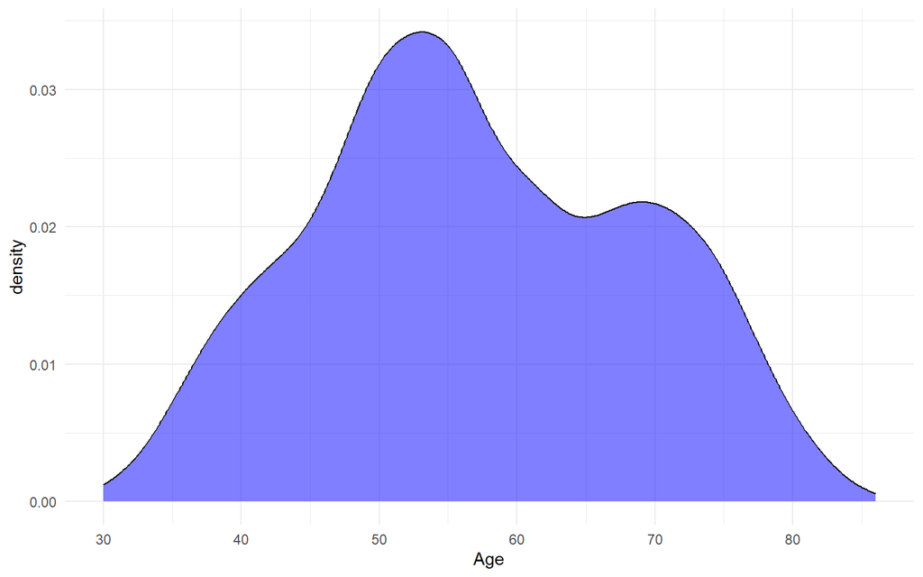

```r
dataframe_processed <- dataframe_cleaning

## Biểu đồ phân phối giá trị
ggplot(dataframe_processed, aes(x = Age)) +
  geom_density(fill = "blue", alpha = 0.5) +
  scale_x_continuous(labels = label_comma()) +
  labs(
    x = "Age"
  ) +
  theme_minimal()
```

Insight:

- Độ tuổi khách hàng trải dài từ 30 - 80 tuổi. Phần lớn tập trung nhiều ở 2 đỉnh ở 50, 70 tuổi.

### Education Distribution

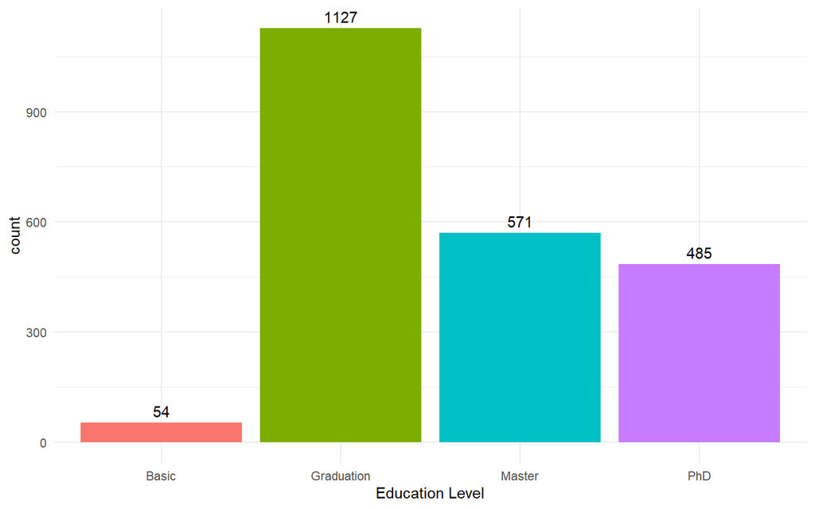

```r
ggplot(dataframe_processed, aes(x = Education, fill = Education)) +
  geom_bar(show.legend = FALSE) +
  geom_text(stat = "count", aes(label = after_stat(count)), vjust = -0.5) +
  labs(
    x = "Education Level"
  ) +
  theme_minimal()
```

Insight:

- Tệp khách hàng tốt nghiệp đại học chiếm số lượng đông nhất. Kế tiếp là các nhóm sau đại học, không có sự chênh lệch nhiều giữa 2 nhóm Thạc sĩ và Tiến sĩ.
- Lượng khách hàng nhóm Phổ thông chỉ 54 người.

### Family Status Distribution

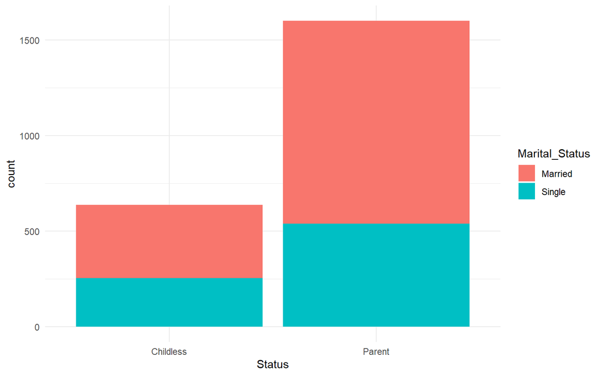

```r
ggplot(dataframe_processed, aes(x = Family_Status, fill = Marital_Status)) +
  geom_bar(show.legend = TRUE) +
  labs(
    x = "Status"
  ) +
  theme_minimal()
```

```r
Table_Family_Status <- dataframe_processed %>%
  group_by(Marital_Status,Family_Status) %>%
  summarise(Count = n())
kable(Table_Family_Status, caption = "")
```

| Marital_Status | Family_Status | Count |
| --- | --- | --- |
| Married | Childless | 383 |
| Married | Parent | 1060 |
| Single | Childless | 254 |
| Single | Parent | 540 |

Insight:

- Tập khách hàng có con chiếm số lượng đông nhất với tổng cộng 1600 người tạo ra sự chênh lệch gấp 2.5 lần so với nhóm khách hàng không con.
- Nhóm độc thân chỉ 794 người so với 1443 người đã kết hôn.

### Income Distribution

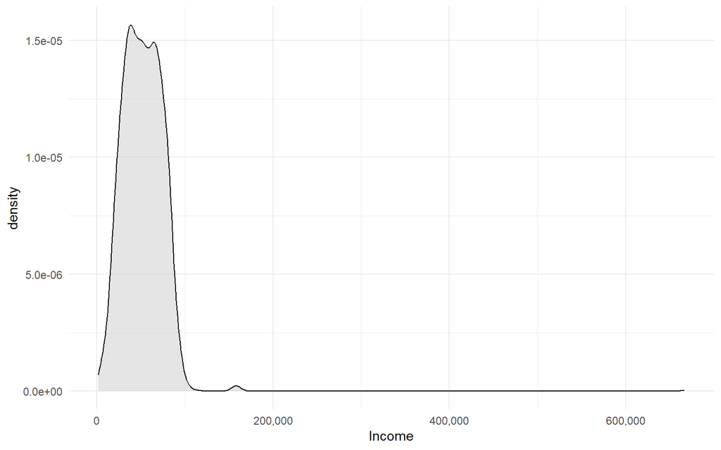

```r
#Biểu đồ phân phối
ggplot(dataframe_processed, aes(x = Income)) +
  geom_density(fill = "gray80", alpha = 0.5) +

  scale_x_continuous(labels = label_comma()) +
  labs(
    x = "Income"
    ) +
  theme_minimal()
```

```r
# Xem xét có thể khách hàng có mức lương trên 200000.

dataframe_processed %>%
   select(ID, Income, Total_Spending, Total_Purchase) %>%
   filter(Income > 200000)
```

```
    ID Income Total_Spending Total_Purchase
1 9432 666666             62              7
```

**Insight**: Xuất hiện giá trị bất thường, 7 lần thanh toán nhưng với mức chi tiêu thấp.

**Hành động**: Lọc khách hàng này để phân tích, không gây thiên lệch.

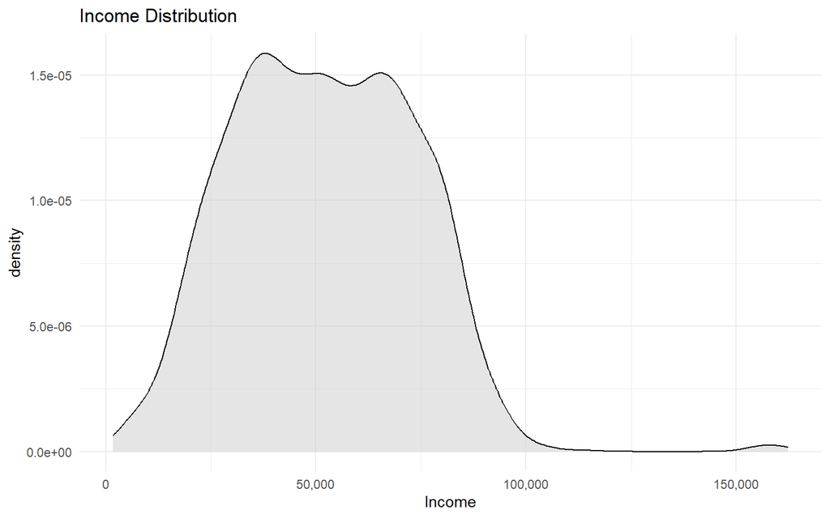

```r
#Lọc khách hàng có mức lương dưới 600000
dataframe_processed <- dataframe_processed %>%
  filter(Income < 600000)

#Biểu đồ phân phối
ggplot(dataframe_processed, aes(x = Income)) +
  geom_density(fill = "gray80", alpha = 0.5) +
  scale_x_continuous(labels = label_comma()) +
  labs(
    title = "Income Distribution",
    x = "Income"
    ) +
  theme_minimal()
```

```r
# Bảng thống kê mức thu nhập
summary(dataframe_processed$Income)
```

```
   Min. 1st Qu.  Median    Mean 3rd Qu.    Max.
   1730   35503   51382   51983   68413  162397
```

**Kết luận:**

- Khách hàng có mức thu nhập tương đối đồng đều và ổn định.
- Xuất hiện một phần đuôi dài từ mốc 100,000. Vẫn còn tồn tại của khách hàng có khả năng chi tiêu vượt trội.

### Total Spending Distribution

```r
# Bảng thống kê Tổng chi tiêu khách hàng
summary(dataframe_processed$Total_Spending)
```

```
   Min. 1st Qu.  Median    Mean 3rd Qu.    Max.
    5.0    69.0   396.5   606.0  1045.5  2525.0
```

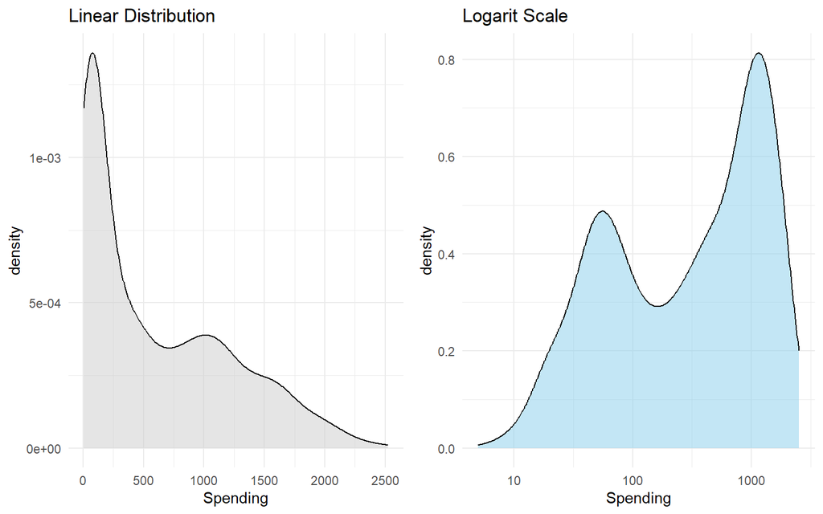

```r
#  Biểu đồ
p1 <- ggplot(dataframe_processed, aes(x = Total_Spending)) +
  geom_density(fill = "gray80", alpha = 0.5) +
  scale_alpha_continuous(labels = label_comma()) +
  labs(title = "Linear Distribution",
       x = "Spending"
       ) +
  theme_minimal()
# Biểu đồ Log
p2 <-  ggplot(dataframe_processed, aes(x = Total_Spending)) +
  geom_density(fill = "skyblue", alpha = 0.5) +
  scale_x_log10() +
  labs(title = "Logarit Scale",
       x = "Spending"
       ) +
  theme_minimal()

grid.arrange(p1, p2, ncol = 2)
```

**Insight**:

- Phân phối Linear: Lệch phải do xuất hiện khách hàng chi tiêu cao với phần còn lại, khó quan sát.
- Khi triệt tiêu độ lệch bằng thang đo Logarit: Phân phối có hai đỉnh. Đỉnh thứ nhất có chi tiêu từ 50-100 và đỉnh thứ hai ở mốc 1000 tạo khoảng cách xa rõ rệt về tổng mức chi tiêu.

### Key Driving Factor

- Độ tuổi khách hàng dao động từ 30 - 80 tuổi, trong đó tập trung nhiều ở phân khúc trung niên từ 50 - 70 tuổi.
- Trình độ Đại học chiếm ưu thế cao nhất với 1127 người, kế đó là 2 bậc sau đại học Thạc Sĩ và Tiến sĩ 571 - 485 không chênh lệch nhiều giữa 2 tệp khách hàng này. Và nhóm phổ thông ít nhất với 54 khách hàng.
- Khách hàng đã có con chiếm đa số với 1600 người bao gồm trạng thái độc thân, và đã kết hôn. Còn không con có quy mô nhỏ 637 người.
- Hành vi chi tiêu mua sắm có sự tách biệt ở 2 nhóm. Nhóm chi tiêu thấp tập trung ở mức 80-$100. Và nhóm chi tiêu cao dao động mức 900 - 1000.

# **Analyze**

Kết hợp các biến nhân khẩu học và hành vi mua sắm đã xử lý trước đó để tìm ra:

1. Phân khúc khách hàng tiềm năng.
2. Nhóm khách hàng có tỷ lệ phản hồi tốt chiến dịch marketing sắp tới.
3. Các kênh bán hàng hiệu quả.
4. Danh mục sản phẩm chủ lực.

## **1. Customer Segments**

### Demographic Segmentation

**1. Correlation Analysis**

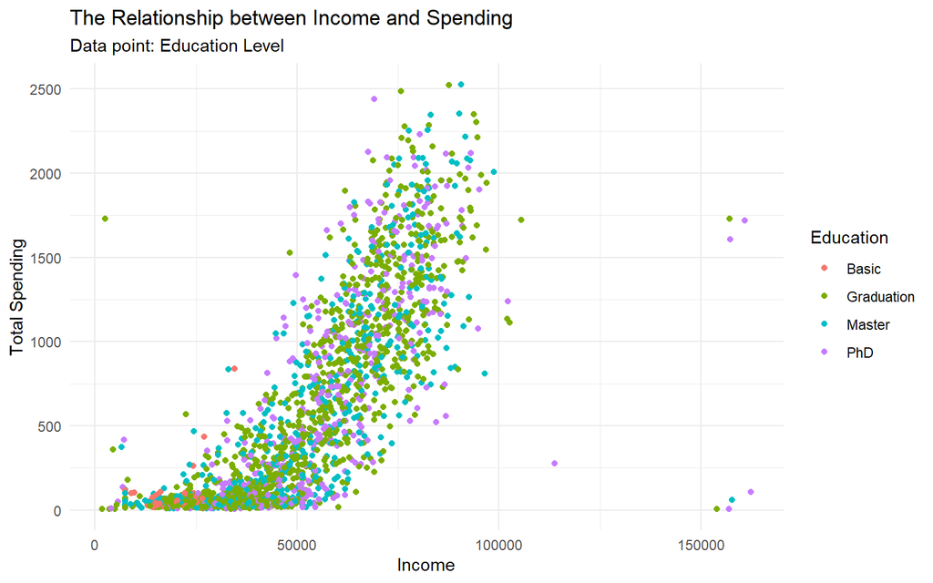

```r
## Kết hợp giữa 2 biến nhân khẩu học: Education , Income
ggplot(dataframe_processed, aes(x = Income, y = Total_Spending)) +
  geom_point(aes(color = Education)) +
  labs(
    title = "The Relationship between Income and Spending",
    subtitle = "Data point: Education Level",
    x = "Income",
    y = "Total Spending"
  ) +
  theme_minimal()
```

Insights:

- Thu nhập cao thường có xu hướng sẽ chi tiêu nhiều.
- Học vị từ đại học trở lên không tạo ra sự khác biệt về chi tiêu, thu nhập.
- Tồn tại các khách hàng ngoại lệ có thu nhập cao thất thường, hành vi chi tiêu rất ít và ngược lại.

**2. Education Segmentation**

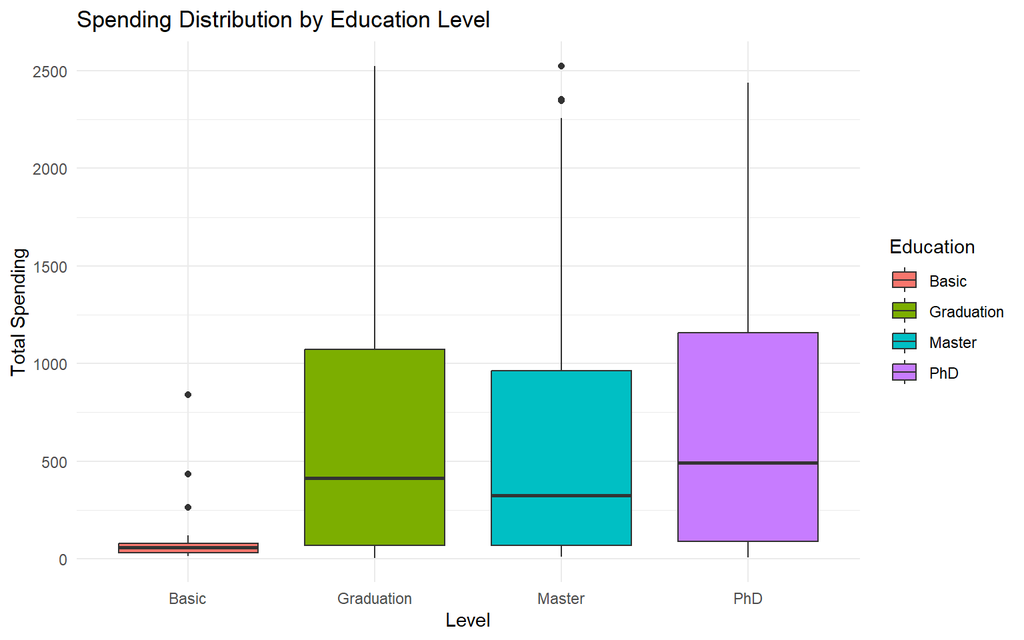

```r
ggplot(dataframe_processed,aes(x = Education, y = Total_Spending, fill = Education)) +
  geom_boxplot() +
  labs(title = "Spending Distribution by Education Level",
       x = "Level",
       y = "Total Spending") +
  theme_minimal()
```

**3. Family Status Segmentation**

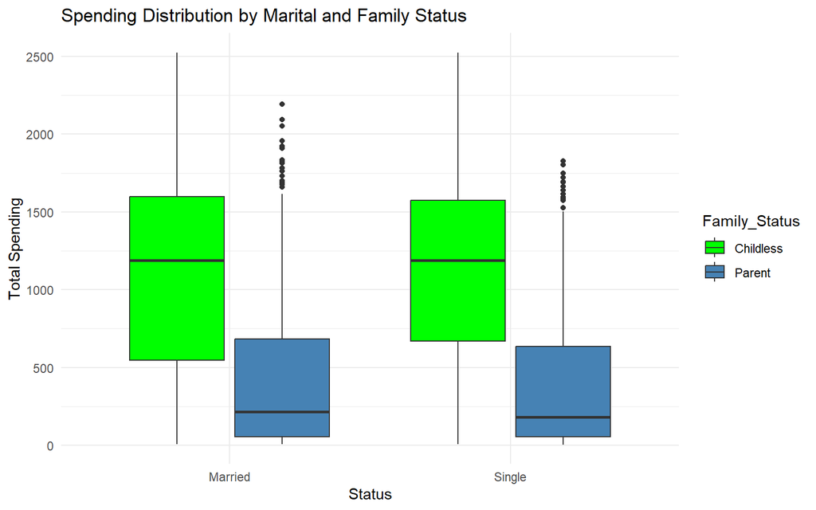

```r
ggplot(dataframe_processed,aes(x = Marital_Status, y = Total_Spending, fill = Family_Status)) +
  geom_boxplot() +
  scale_fill_manual(values = c("green", "steelblue")) +
  labs(title = "Spending Distribution by Marital and Family Status",
       x = "Status",
       y = "Total Spending") +
  theme_minimal()
```

Insights:

- Việc có con hay không là yếu tố quyết định sức mua của khách hàng. Nhóm không con sở hữu mức chi tiêu áp đảo với trung vị lên tới khoảng $1,200. Trong khi đó sức mua của nhóm Parent mức trung vị ở khoảng 200.
- Trạng thái Kết hôn hay độc thân không ảnh hưởng gì đến hành vi chi tiêu. Yếu tố con cái gây ảnh hưởng mạnh nhất.
- Tồn tại những khách hàng ngoại lai chi tiêu khá cao mặc dù đã có con. Khác biệt với nhóm còn lại.

### Behavioral Segmentation

Phân khúc khách hàng dựa trên mức tỷ lệ suy ra hành vi như sau:

- Deal Dependency bằng $0$: Không sử dụng.
- Deal Dependency thuộc khoảng $(0, 0.2]$: Vừa phải.
- Deal Dependency trên $0.2$ : Thường xuyên.

```r
# Tạo Biến về tỷ lệ sử dụng khuyến mãi
dataframe_processed <- dataframe_processed %>%
  mutate(Deal_Dependency = ifelse(Total_Purchase != 0,
                                  NumDealsPurchases / Total_Purchase,0))
# Tứ phân vị của Biến Deal_Dependency
quantile(dataframe_processed$Deal_Dependency)
```

```
         0%         25%         50%         75%        100%
 0.00000000  0.08333333  0.20000000  0.33333333 15.00000000
```

```r
# Tạo biến phân khúc khách hàng cho dataframe
dataframe_Analyze <- dataframe_processed %>%
  mutate(Deal_Group = case_when(Deal_Dependency == 0 ~ "No Deal",
                                Deal_Dependency > 0 & Deal_Dependency <= 0.2 ~ "Moderate",
                                Deal_Dependency > 0.2  ~ "Frequent"),
        Deal_Group = factor(Deal_Group, levels = c("No Deal",
                                                   "Moderate",
                                                   "Frequent")))
```

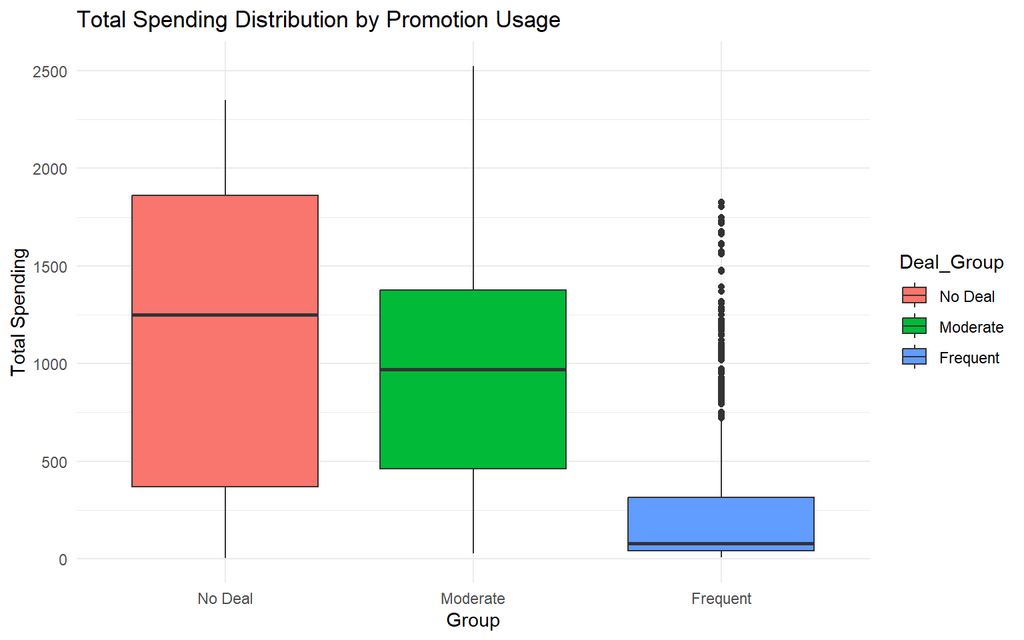

```r
ggplot(dataframe_Analyze,aes(x = Deal_Group, y = Total_Spending, fill = Deal_Group)) +
  geom_boxplot() +
  labs(title = "Total Spending Distribution by Promotion Usage",
       x = "Group",
       y = "Total Spending") +
  theme_minimal()
```

Insights:

- Không sử dụng, vừa phải: là lượng khác hàng mang lại giá trị chi tiêu cao. Đường trung vị của hai nhóm này ở mức rất cao khoảng 1,000 - $1,250, kết hợp dải phạm vi rộng chứng tỏ sức mua của họ rất tự nhiên, linh hoạt. Không bị ảnh hưởng bởi giảm giá
- Thường xuyên: Mức chi tiêu cốt lõi cực thấp. Trung vị nằm gần sát đáy quanh mức $100 và phần lớn dữ liệu co cụm ở vùng chi tiêu hẹp. Tuy vậy vẫn có một số khách hàng có khả năng chi tiêu mạnh.

```r
# Tạo biến tổng doanh thu cho từng nhóm
# Table
Table_2 <- dataframe_Analyze %>%
  group_by(Deal_Group) %>%
  summarise(Count = n(),
            Total_Revenue = sum(Total_Spending),
            Average_Total_Spending = mean(Total_Spending),
            Total_Accept_Cmpt = sum(AcceptedCmp1 +
                                     AcceptedCmp2 +
                                     AcceptedCmp3 +
                                     AcceptedCmp4 +
                                     AcceptedCmp5))

kable(Table_2,caption = "Total Spending Table by Promotion Usage")
```

Total Spending Table by Promotion Usage

| Deal_Group | Count | Total_Revenue | Average_Total_Spending | Total_Accept_Cmpt |
| --- | --- | --- | --- | --- |
| No Deal | 48 | 56816 | 1183.6667 | 57 |
| Moderate | 1084 | 1031938 | 951.9723 | 462 |
| Frequent | 1104 | 266232 | 241.1522 | 147 |

### Key Driving Factors

- Thu nhập & Gia đình: Khách hàng thu nhập cao và không vướng bận con cái là thường có chi tiêu cao.
- Hành vi mua sắm: Việc phụ thuộc mã giảm giá tỷ lệ nghịch với giá trị vòng đời khách hàng. Nhóm có bình quân chi tiêu cao và ổn định nằm ở hành vi không phụ thuộc vào sử dụng khuyến mãi.

## **2. Response Rate Analysis**

### Target Marketing: Income & Behavior

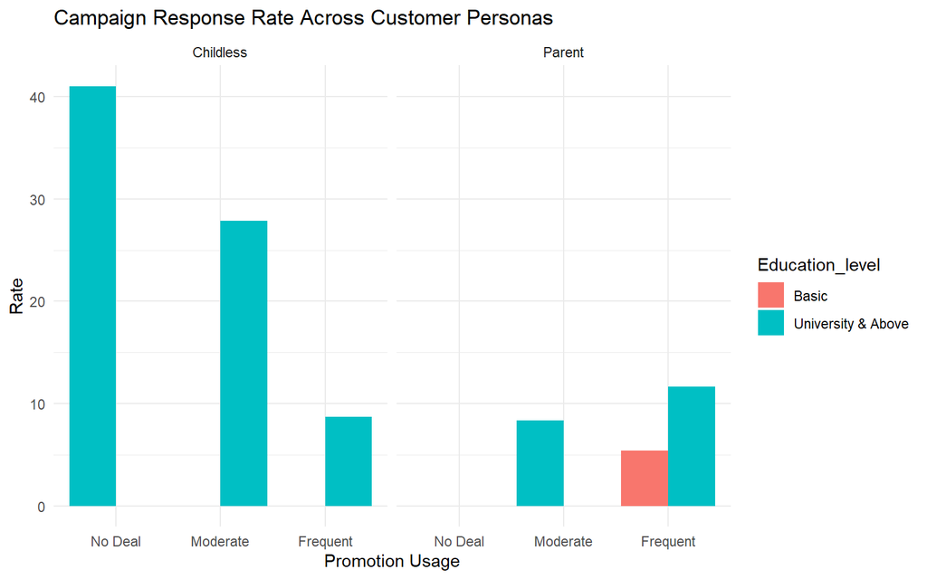

```r
## - Nhóm Khách hàng sẽ được chia theo nhân khẩu học và hành vi mua sắm

dataframe_Marketing <- dataframe_Analyze %>%
  mutate(Education_level = case_when(Education %in% c("Graduation", "Master", "PhD", "2n Cycle") ~ "University & Above", TRUE ~ "Basic"))

## Tạo bảng tổng hợp phục vụ Marketing.
Marketing_Table <- dataframe_Marketing %>%
  group_by(Education_level, Deal_Group, Family_Status) %>%
  summarise(Count = n(),
            Total_Response = sum(Response),
            Response_Rate_Campaign = mean(Response) * 100, # Chấp nhận chiến dịch cuối
            Total_Accept_Cmpt      = sum(AcceptedCmp1 +
                                     AcceptedCmp2 +
                                     AcceptedCmp3 +
                                     AcceptedCmp4 +
                                     AcceptedCmp5 ))

## Vẽ biểu đồ dựa trên bảng tổng hợp
ggplot(Marketing_Table, aes(x = Deal_Group, y = Response_Rate_Campaign, fill = Education_level)) +
  geom_bar(stat = "identity", position = position_dodge(preserve = "single")) +
  facet_wrap(~Family_Status) +
  labs(
    title = "Campaign Response Rate Across Customer Personas",
    x = "Promotion Usage",
    y = "Rate"
  ) +
  theme_minimal()
```

```r
Marketing_Table <- dataframe_Marketing %>%
  filter(Education_level == "University & Above", Family_Status == "Childless") %>%
  group_by(Deal_Group) %>%
  summarise(Count = n(),
            Total_Response = sum(Response),
            Response_Rate_Campaign = mean(Response) * 100,
            Previous_Campagin = sum(AcceptedCmp5))# Chấp nhận chiến dịch cuối

kable(Marketing_Table, caption = "Campaign Response Rate Childless")
```

Campaign Response Rate Childless

| Deal_Group | Count | Total_Response | Response_Rate_Campaign | Previous_Campagin |
| --- | --- | --- | --- | --- |
| No Deal | 39 | 16 | 41.025641 | 21 |
| Moderate | 535 | 149 | 27.850467 | 116 |
| Frequent | 46 | 4 | 8.695652 | 0 |

Insight:

- Nhóm có tỷ lệ phản hồi tốt ở chiến dịch tiếp theo nằm ở Childless.
- Childless - No Deal: tỷ lệ phản hồi cao nhất với 41%, nhóm này ưu tiên việc trải nghiệm, chăm sóc hậu mãi hơn là quan tâm về giá. Có sự giảm nhẹ về tương tác so với chiến dịch trước.
- Childless - Moderate: có 149 khách hàng hưởng ứng chiến dịch tiếp theo.
- Nhóm khách hàng có tỷ lệ phản hồi tốt cho chiến dịch khách hàng sắp tới có nhân khẩu học không con, và hành vi mua sắm không phụ thuộc khuyến mãi.

## **3. Purchase Channel Analysis**

```r
# 1. Lọc dữ liệu VIP và tính tỷ trọng Kênh mua sắm
vip_channel_data <- dataframe_Marketing %>%
  filter(Education_level == "University & Above", Deal_Group %in% c("No Deal","Moderate")) %>%
  summarise(
    Store = sum(NumStorePurchases),
    Web = sum(NumWebPurchases),
    Catalog = sum(NumCatalogPurchases)
  ) %>%
  # Pivot table
  pivot_longer(cols = everything(), names_to = "Channel", values_to = "Orders") %>%
  mutate(Percentage = round(Orders / sum(Orders) * 100, 1)) %>%
  arrange(desc(Percentage))
kable(vip_channel_data, caption = "")
```

| Channel | Orders | Percentage |
| --- | --- | --- |
| Store | 8406 | 44.5 |
| Web | 5764 | 30.5 |
| Catalog | 4722 | 25.0 |

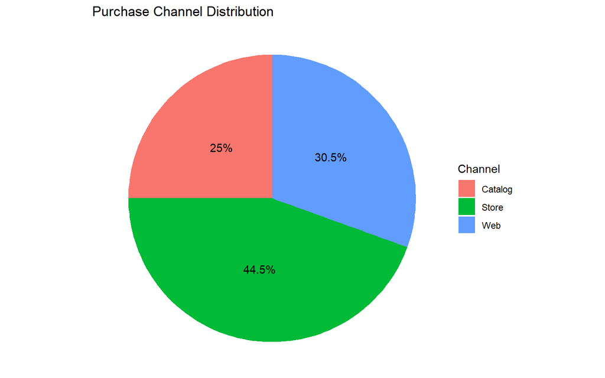

```r
# 2. Vẽ Pie Chart
ggplot(vip_channel_data, aes(x = "", y = Orders, fill = Channel)) +
  geom_bar(stat = "identity", width = 1) +
  coord_polar("y", start = 0) +
  geom_text(aes(label = paste0(Percentage, "%")), position = position_stack(vjust = 0.5)) +
  labs(title = "Purchase Channel Distribution", fill = "Channel") +
  theme_void()
```

**Insight**:

- Store chiếm 44.5% là kênh chủ lực với tổng lượng đơn 8406. Phần lớn tệp khách hàng thích được trải nghiệm sản phẩm trực tiếp và quan tâm đến chất lượng dịch vụ.
- Kế đó Website, chiếm 30.5%, nhóm khách hàng thích sự tiện lợi bằng cách mua online mà không cần trực tiếp ra cửa hàng.
- Cuối cùng là 25% Catalog, nhóm này thích tìm hiểu sâu, và thích đọc những câu chuyện về sản phẩm, văn hoá độc quyền.

## **4. Product Preferences Analysis**

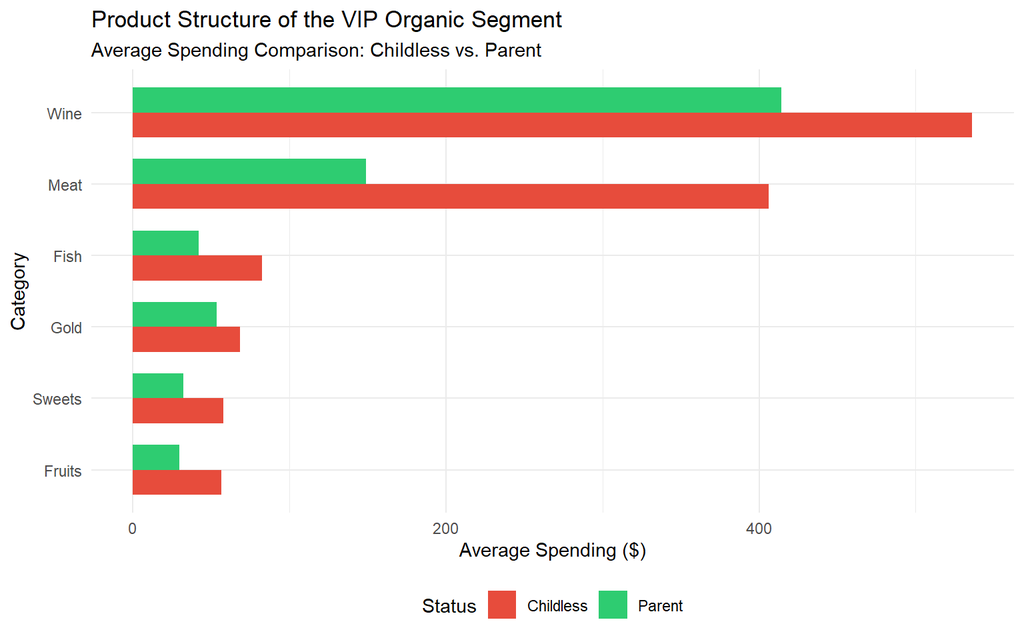

```r
# 1. Lọc dữ liệu VIP và tính trung bình chi tiêu theo HỌc vị và trạng thái gia đình
vip_product_data <- dataframe_Marketing %>%
  filter(Education_level == "University & Above", Deal_Group %in%  c("No Deal","Moderate")) %>%
  group_by(Family_Status) %>%
  summarise(
    Wine = mean(MntWines),
    Meat = mean(MntMeatProducts),
    Fish = mean(MntFishProducts),
    Gold = mean(MntGoldProds),
    Sweets = mean(MntSweetProducts),
    Fruits = mean(MntFruits)
  ) %>%
  pivot_longer(cols = -Family_Status, names_to = "Product", values_to = "Avg_Spending")

# 2. Dodged Bar Chart
ggplot(vip_product_data, aes(x = reorder(Product, Avg_Spending), y = Avg_Spending, fill = Family_Status)) +
  # Thêm position = "dodge" để tách 2 cột ra đứng cạnh nhau
  geom_col(position = "dodge", width = 0.7) +
  coord_flip() +
  theme_minimal() +
  scale_fill_manual(values = c("Childless" = "#E74C3C", "Parent" = "#2ECC71")) +
  labs(
    title = "Product Structure of the VIP Organic Segment",
    subtitle = "Average Spending Comparison: Childless vs. Parent",
    x = "Category",
    y = "Average Spending ($)",
    fill = "Status"
  ) +
  theme(legend.position = "bottom")
```

**Insight**:

- Rượu là danh mục doanh thu chủ lực của toàn bộ tập khách hàng này. Nhóm khách hàng Không con có sức mua áp đảo với mức chi tiêu trung bình vượt ngưỡng 500$.
- Có sự chênh lệch rõ nằm ở mặt hàng Thịt. Nhóm không con có thể trả mức chi tiêu cao gấp 3 lần với nhóm có con.
- Các mặt hàng còn lại, nhóm Childless mức chi tiêu vượt trội hoàn toàn so với nhóm Parent.